# The relationship between a translational cognitive measure of negative bias and self-reported psychiatric symptoms in a large online sample

# Background

This study builds on prior work developing a measure of negative affective bias as indexed by proportion of mid tones interpreted as high reward (‘p(mid as high)’) in A) a rat pharmacological model of mood and anxiety disorders (Hales et al., 2016) and B) humans with mood and anxiety disorders relative to healthy controls (Aylward et al., 2019).

#### Next steps

This prior work suggests that this cognitive measure is sensitive to pathological symptoms. We have three objectives for the present study. Firstly we wanted to explore and remove sources of between-subject bias within the task so as to maximise our chances of measuring individual differences in task performance. Secondly, we wanted to explore factors which contribute to individual differences in task performance in a large cross-sectional sample. Specifically, we are interested in which specific psychiatric-relevant symptoms/traits contribute to task performance. Finally, once we identify relevant traits, can we re-capitulate the effect of clinical screening in a large unscreened online sample?

# 1: Piloting to explore sources of between-subject bias

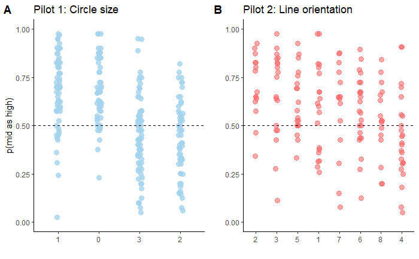

```
             Df Sum Sq Mean Sq F value Pr(>F)
group         3  3.964  1.3215   35.28 <2e-16 ***
Residuals   260  9.739  0.0375
---
Signif. codes:  0 ‘***’ 0.001 ‘**’ 0.01 ‘*’ 0.05 ‘.’ 0.1 ‘ ’ 1
         eta.sq eta.sq.part
group 0.2893019   0.2893019
             Df Sum Sq Mean Sq F value  Pr(>F)
group         7  0.929 0.13267   3.077 0.00475 **
Residuals   143  6.165 0.04311
---
Signif. codes:  0 ‘***’ 0.001 ‘**’ 0.01 ‘*’ 0.05 ‘.’ 0.1 ‘ ’ 1
         eta.sq eta.sq.part
group 0.1309089   0.1309089
  Tukey multiple comparisons of means
    95% family-wise confidence level

Fit: aov(formula = Pmid ~ group, data = pilot1cb)

$group
           diff         lwr        upr     p adj
1-0  0.03319086 -0.05510565  0.1214874 0.7655217
2-0 -0.24185068 -0.33400241 -0.1496990 0.0000000
3-0 -0.21067170 -0.29843425 -0.1229092 0.0000000
2-1 -0.27504154 -0.36251921 -0.1875639 0.0000000
3-1 -0.24386256 -0.32670376 -0.1610213 0.0000000
3-2  0.03117898 -0.05575969  0.1181177 0.7902342

  Tukey multiple comparisons of means
    95% family-wise confidence level

Fit: aov(formula = Pmid ~ group, data = pilot2cb)

$group
            diff         lwr         upr     p adj
2-1  0.116847213 -0.10133355  0.33502797 0.7205659
3-1  0.076216643 -0.12842007  0.28085336 0.9453463
4-1 -0.150419157 -0.34381573  0.04297742 0.2529895
5-1  0.033392280 -0.17124444  0.23802900 0.9996371
6-1 -0.012709407 -0.20800766  0.18258885 0.9999993
```

[output cut: 8 more lines]

```
4-3 -0.226635800 -0.42278876 -0.03048284 0.0117584
5-3 -0.042824363 -0.25006802  0.16441930 0.9983082
6-3 -0.088926050 -0.28695422  0.10910212 0.8642912
7-3 -0.079038143 -0.29966587  0.14158958 0.9554490
8-3 -0.133453390 -0.35019400  0.08328722 0.5571819
5-4  0.183811438 -0.01234152  0.37996440 0.0838114
6-4  0.137709750 -0.04868018  0.32409968 0.3158952
7-4  0.147597657 -0.06264658  0.35784190 0.3824994
8-4  0.093182411 -0.11297903  0.29934385 0.8602737
6-5 -0.046101687 -0.24412986  0.15192649 0.9964027
7-5 -0.036213780 -0.25684150  0.18441394 0.9996228
8-5 -0.090629027 -0.30736963  0.12611158 0.9025639
7-6  0.009887907 -0.20210694  0.22188275 0.9999999
8-6 -0.044527340 -0.25247376  0.16341908 0.9978766
8-7 -0.054415247 -0.28398691  0.17515642 0.9959758
```

#### Interpretation

Both tasks demonstrate clear sources of between-subject bias. In short, individuals demonstrated ‘higher’ bias when large (or vertical) stimuli were paired with large rewards on the right hand side. These reflect pre-potent biases (e.g. bigger things usually cost more and in latinate languages we read from left to right etc.). Smaller biases were observed when the stimulus-response-outcome contingencies were incongruent with these pre-potent biases. These biases add to the noise in within-subject or case-control designs, but effects can still be observed over and above these effects. Unfortunately if we care about within-subject differences in a cross-sectional design we have to remove this. We decided to restrict further testing to the intermediate bias scores on pilot 2 (counterbalancing 1 and 7). Thus we would need to control for counterbalancing but would only have two groups (rather than 8). Of note, we chose pilot 2 design rather than pilot 1 because a circle has both area and diameter that a participant may attend to, whereas there is only one interpretation of line orientation.

# 2: Exploring contributors to bias in cross-sectional data

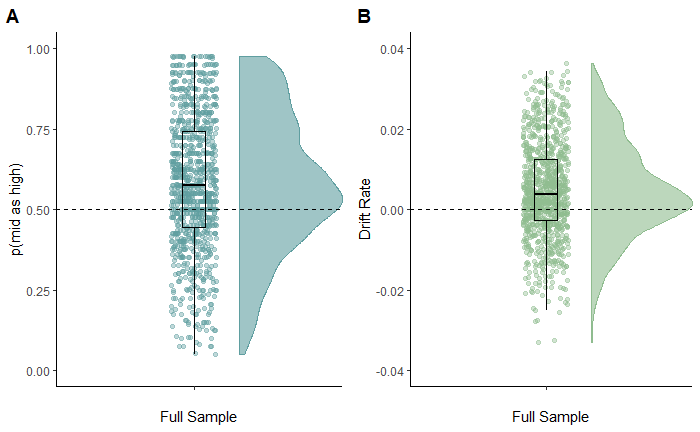

```
    One Sample t-test

data:  combineditemdata$propmedhigh
t = 12.087, df = 989, p-value < 2.2e-16
alternative hypothesis: true mean is not equal to 0.5
95 percent confidence interval:
 0.5673667 0.5934807
sample estimates:
mean of x
0.5804237


    One Sample t-test

data:  combineditemdata$driftrate
t = 12.122, df = 989, p-value < 2.2e-16
alternative hypothesis: true mean is not equal to 0
95 percent confidence interval:
 0.003860173 0.005351423
sample estimates:
  mean of x
0.004605798
```

|  | mean | std | lower range | upper range |
| --- | --- | --- | --- | --- |
| Age | 34 | 10 | 18 | 76 |
| Ravens | 4 | 3 | 0 | 12 |
| OCIR | 24 | 18 | 0 | 72 |
| SZ | 16 | 9 | 0 | 51 |
| BDI | 15 | 12 | 0 | 56 |
| STAI | 45 | 12 | 20 | 78 |

```
Split half reliabilities
Call: splitHalf(r = dataforsh, raw = T, brute = FALSE, n.sample = 1e+05,
    covar = FALSE, check.keys = TRUE, key = NULL, ci = 0.05,
    use = "pairwise")

Maximum split half reliability (lambda 4) =  0.94
Guttman lambda 6                          =  0.93
Average split half reliability            =  0.91
Guttman lambda 3 (alpha)                  =  0.91
Guttman lambda 2                          =  0.92
Minimum split half reliability  (beta)    =  0.85
Average interitem r =  0.21  with median =  0.21
                                             2.5% 50% 97.5%
 Quantiles of split half reliability      =  0.9 0.92 0.93
```

### Simple Linear Regression of measures

To explore the impact of trait/demographic measures on task performance we next ran a linear regression (using Robust ML estimator for consistency with SEM below) to predict p(mid as high)(‘propmedhigh’ variable) and drift rate. The variables we included are:

- Spreadsheet (categorical): represents the counterbalancing condition
- Ravens (continuous): IQ measure (visual matrices)
- Age (continuous): years old
- BDI (continuous): Beck depression inventory (suicide question removed)
- STAI2 (continuous): Spielberger Trait Anxiety
- OCIR (continuous): Obsessive-Compulsive Inventory (Revised)
- SZ (continuous): Schizotypal short scale
- GenderMF (categorical): Self-reported gender

```r
NegBiasmodel.1 <- 'propmedhigh ~ GenderMF + Age + Ravens + spreadsheet +BDI + STAI2 + SZ + OCIR'
NegBiasmodel.2 <- 'driftrate ~ GenderMF + Age + Ravens + spreadsheet +BDI + STAI2 + SZ + OCIR'


fit1 <- sem(NegBiasmodel.1, data=combineditemdata, meanstructure=TRUE,  estimator = "MLR")
fit2 <- sem(NegBiasmodel.2, data=combineditemdata, meanstructure=TRUE,  estimator = "MLR")
fit1miss <- sem(NegBiasmodel.1, data=combineditemdata, meanstructure=TRUE,  estimator = "MLR", missing = "ML")
fit2miss <- sem(NegBiasmodel.2, data=combineditemdata, meanstructure=TRUE,  estimator = "MLR", missing = "ML")



summary(fit1, standardized=TRUE, rsquare=T, fit.measures=F) #p(mid as high) listwise delete missing
```

```
lavaan 0.6-5 ended normally after 57 iterations

  Estimator                                         ML
  Optimization method                           NLMINB
  Number of free parameters                         10

                                                  Used       Total
  Number of observations                           986        1060

Model Test User Model:
                                              Standard      Robust
  Test Statistic                                 0.000       0.000
  Degrees of freedom                                 0           0

Parameter Estimates:

  Information                                      Observed
  Observed information based on                     Hessian
  Standard errors                        Robust.huber.white

Regressions:
                   Estimate  Std.Err  z-value  P(>|z|)   Std.lv  Std.all
  propmedhigh ~
    GenderMF          0.017    0.014    1.265    0.206    0.017    0.041
    Age              -0.002    0.001   -3.471    0.001   -0.002   -0.110
    Ravens            0.010    0.002    4.328    0.000    0.010    0.144
    spreadsheet       0.006    0.002    2.682    0.007    0.006    0.084
    BDI              -0.002    0.001   -2.427    0.015   -0.002   -0.124
    STAI2             0.001    0.001    0.890    0.373    0.001    0.041
    SZ               -0.001    0.001   -1.038    0.299   -0.001   -0.052
    OCIR             -0.000    0.001   -0.021    0.984   -0.000   -0.001

Intercepts:
                   Estimate  Std.Err  z-value  P(>|z|)   Std.lv  Std.all
   .propmedhigh       0.642    0.043   14.807    0.000    0.642    3.065

Variances:
                   Estimate  Std.Err  z-value  P(>|z|)   Std.lv  Std.all
   .propmedhigh       0.041    0.002   24.734    0.000    0.041    0.943

R-Square:
                   Estimate
    propmedhigh       0.057
```

```r
summary(fit2, standardized=TRUE, rsquare=T, fit.measures=F) #driftrate listwise delete missing
```

```
lavaan 0.6-5 ended normally after 112 iterations

  Estimator                                         ML
  Optimization method                           NLMINB
  Number of free parameters                         10

                                                  Used       Total
  Number of observations                           986        1060

Model Test User Model:
                                              Standard      Robust
  Test Statistic                                 0.000       0.000
  Degrees of freedom                                 0           0

Parameter Estimates:

  Information                                      Observed
  Observed information based on                     Hessian
  Standard errors                        Robust.huber.white

Regressions:
                   Estimate  Std.Err  z-value  P(>|z|)   Std.lv  Std.all
  driftrate ~
    GenderMF          0.001    0.001    1.081    0.280    0.001    0.035
    Age              -0.000    0.000   -3.272    0.001   -0.000   -0.104
    Ravens            0.001    0.000    4.343    0.000    0.001    0.146
    spreadsheet       0.000    0.000    2.704    0.007    0.000    0.084
    BDI              -0.000    0.000   -2.590    0.010   -0.000   -0.130
    STAI2             0.000    0.000    0.945    0.345    0.000    0.044
    SZ               -0.000    0.000   -1.236    0.216   -0.000   -0.062
    OCIR              0.000    0.000    0.297    0.767    0.000    0.014

Intercepts:
                   Estimate  Std.Err  z-value  P(>|z|)   Std.lv  Std.all
   .driftrate         0.008    0.002    3.146    0.002    0.008    0.653

Variances:
                   Estimate  Std.Err  z-value  P(>|z|)   Std.lv  Std.all
   .driftrate         0.000    0.000   21.305    0.000    0.000    0.943

R-Square:
                   Estimate
    driftrate         0.057
```

```r
summary(fit1miss, standardized=TRUE, rsquare=T, fit.measures=F) #p(mid as high) estimate missing
```

```
lavaan 0.6-5 ended normally after 57 iterations

  Estimator                                         ML
  Optimization method                           NLMINB
  Number of free parameters                         10

                                                  Used       Total
  Number of observations                           986        1060
  Number of missing patterns                         1

Model Test User Model:
                                              Standard      Robust
  Test Statistic                                 0.000       0.000
  Degrees of freedom                                 0           0

Parameter Estimates:

  Information                                      Observed
  Observed information based on                     Hessian
  Standard errors                        Robust.huber.white

Regressions:
                   Estimate  Std.Err  z-value  P(>|z|)   Std.lv  Std.all
  propmedhigh ~
    GenderMF          0.017    0.014    1.265    0.206    0.017    0.041
    Age              -0.002    0.001   -3.471    0.001   -0.002   -0.110
    Ravens            0.010    0.002    4.328    0.000    0.010    0.144
    spreadsheet       0.006    0.002    2.682    0.007    0.006    0.084
    BDI              -0.002    0.001   -2.427    0.015   -0.002   -0.124
    STAI2             0.001    0.001    0.890    0.373    0.001    0.041
    SZ               -0.001    0.001   -1.038    0.299   -0.001   -0.052
    OCIR             -0.000    0.001   -0.021    0.984   -0.000   -0.001

Intercepts:
                   Estimate  Std.Err  z-value  P(>|z|)   Std.lv  Std.all
   .propmedhigh       0.642    0.043   14.807    0.000    0.642    3.065

Variances:
                   Estimate  Std.Err  z-value  P(>|z|)   Std.lv  Std.all
   .propmedhigh       0.041    0.002   24.734    0.000    0.041    0.943

R-Square:
                   Estimate
    propmedhigh       0.057
```

```r
summary(fit2miss, standardized=TRUE, rsquare=T, fit.measures=F) #drift rate estimate missing
```

```
lavaan 0.6-5 ended normally after 112 iterations

  Estimator                                         ML
  Optimization method                           NLMINB
  Number of free parameters                         10

                                                  Used       Total
  Number of observations                           986        1060
  Number of missing patterns                         1

Model Test User Model:
                                              Standard      Robust
  Test Statistic                                 0.000       0.000
  Degrees of freedom                                 0           0

Parameter Estimates:

  Information                                      Observed
  Observed information based on                     Hessian
  Standard errors                        Robust.huber.white

Regressions:
                   Estimate  Std.Err  z-value  P(>|z|)   Std.lv  Std.all
  driftrate ~
    GenderMF          0.001    0.001    1.081    0.280    0.001    0.035
    Age              -0.000    0.000   -3.272    0.001   -0.000   -0.104
    Ravens            0.001    0.000    4.343    0.000    0.001    0.146
    spreadsheet       0.000    0.000    2.704    0.007    0.000    0.084
    BDI              -0.000    0.000   -2.590    0.010   -0.000   -0.130
    STAI2             0.000    0.000    0.945    0.345    0.000    0.044
    SZ               -0.000    0.000   -1.236    0.216   -0.000   -0.062
    OCIR              0.000    0.000    0.297    0.767    0.000    0.014

Intercepts:
                   Estimate  Std.Err  z-value  P(>|z|)   Std.lv  Std.all
   .driftrate         0.008    0.002    3.146    0.002    0.008    0.653

Variances:
                   Estimate  Std.Err  z-value  P(>|z|)   Std.lv  Std.all
   .driftrate         0.000    0.000   21.305    0.000    0.000    0.943

R-Square:
                   Estimate
    driftrate         0.057
```

#### Interpretation

Affective bias and drift rate are both significantly influenced by IQ, Age, BDI and counterbalancing only. Thus of mental health relevant symptoms, task performance appears to be more driven by depresson than anxiety, OCD, or psychosis related traits.

### Correlation between task performance and depression symptoms

To illustrate the effect of depression in the regression we plot the correlation between BDI and pmidhigh/drift rate in raw scores. Consistent with our prior work, increased depression is associated with reduced p(mid as high)(i.e. increased negative bias).

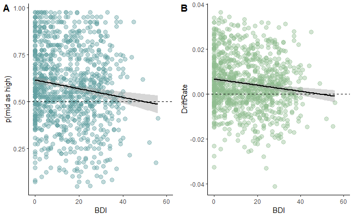

```
    Pearson's product-moment correlation

data:  combineditemdata$BDI and combineditemdata$propmedhigh
t = -4.1597, df = 988, p-value = 3.464e-05
alternative hypothesis: true correlation is not equal to 0
95 percent confidence interval:
 -0.19192938 -0.06945488
sample estimates:
       cor
-0.1311927


    Pearson's product-moment correlation

data:  combineditemdata$BDI and combineditemdata$driftrate
t = -4.3094, df = 988, p-value = 1.801e-05
alternative hypothesis: true correlation is not equal to 0
95 percent confidence interval:
 -0.19647238 -0.07415159
sample estimates:
       cor
-0.1358296
```

### Exploring latent variable structure of the Questionnaires

The linear regression assumes that the summary scores of the questionnaires represent discrete categories. However, it is possible that effects are driven by a generic ‘mental ill health’ factor (sometimes referred to as a P factor model). Or, some questionnaires (e.g. BDI and trait anxiety, which are usually highly correlated) actually meausure a single latent ‘negative affect’ factor. To test for these possibilities we explore four confirmatory factor analyses feeding the individual items from the questionnaires into 1-4 latent factors. The 4 latent factor CFA represents the items feeding into the original questionnaires.

```r
###Testing different measurement models

pFactor1<-'#specifying measurement model

P   =~ BDI_Appetite_quantised   +
       BDI_Attractive_quantised +
       BDI_Blame_quantised  +
       BDI_Cry_quantised    +
       BDI_Decisions_quantised  +
       BDI_Disappointment_quantised +
       BDI_Failure_quantised    +
       BDI_Future_quantised +
       BDI_Guilty_quantised +
       BDI_Health_quantised +
       BDI_Interest_In_People_quantised +
       BDI_Irritated_quantised  +
       BDI_Libido_quantised +
       BDI_Punished_quantised   +
       BDI_Sad_quantised +
       BDI_Satisfaction_quantised   +
       BDI_Sleep_quantised  +
       BDI_Tired_quantised  +
       BDI_weight_quantised +
       BDI_Work_quantised   +
        STAI2_Calm_quantised +
        STAI2_Content_quantised +
        STAI2_Desicions_quantised +
        STAI2_Difficulties_quantised +
        STAI2_DisappointmentsSelf_quantised +
        STAI2_Failure_quantised +
        STAI2_Happy_quantised +
        STAI2_HappyOthers_quantised +
        STAI2_Inadequate_quantised +
        STAI2_Nervous_quantised +
        STAI2_Pleasant_quantised +
        STAI2_Rested_quantised +
        STAI2_SatisfiedSelf_quantised +
        STAI2_Secure_quantised +
        STAI2_SelfConfidence_quantised +
        STAI2_Steady_quantised +
        STAI2_Tension_quantised +
        STAI2_Thoughts_quantised +
        STAI2_UnimportantThought_quantised +
        STAI2_Worry_quantised +
       OCIR_14_quantised    +
       OCIR_15_quantised    +
       OCIR_16_quantised    +
       OCIR_17_quantised    +
       OCIR_18_quantised    +
       OCIR_2_quantised +
       OCIR_3_quantised +
       OCIR_4_quantised +
       OCIR_5_quantised +
       OCIR_6_quantised +
       OCIR_7_quantised +
       OCIR_8_quantised +
       OCIR_9_quantised +
       OCIR_1_quantised +
       OCIR_10_quantised    +
       OCIR_11_quantised    +
       OCIR_12_quantised    +
       OCIR_13_quantised  +
      SZ_1_quantised    +
      SZ_10_quantised   +
      SZ_11_quantised +
      SZ_12_quantised +
      SZ_13_quantised +
      SZ_14_quantised +
      SZ_15_quantised +
      SZ_16_quantised +
      SZ_17_quantised +
      SZ_18_quantised +
      SZ_19_quantised +
      SZ_2_quantised +
      SZ_20_quantised +
      SZ_21_quantised +
      SZ_22_quantised +
      SZ_23_quantised +
      SZ_24_quantised +
      SZ_25_quantised +
      SZ_26_quantised +
      SZ_27_quantised +
      SZ_28_quantised +
      SZ_29_quantised +
      SZ_3_quantised +
      SZ_30_quantised +
      SZ_31_quantised +
      SZ_32_quantised +
      SZ_33_quantised +
      SZ_34_quantised +
      SZ_35_quantised +
      SZ_36_quantised +
      SZ_37_quantised +
      SZ_38_quantised +
      SZ_39_quantised +
      SZ_4_quantised +
      SZ_40_quantised +
      SZ_41_quantised +
      SZ_42_quantised +
      SZ_5_quantised +
      SZ_6_quantised +
      SZ_7_quantised +
      SZ_8_quantised +
      SZ_9_quantised
'

BiFactor2<-'#specifying measurement model

ANXDEP =~ BDI_Appetite_quantised    +
       BDI_Attractive_quantised +
       BDI_Blame_quantised  +
       BDI_Cry_quantised    +
       BDI_Decisions_quantised  +
       BDI_Disappointment_quantised +
       BDI_Failure_quantised    +
       BDI_Future_quantised +
       BDI_Guilty_quantised +
       BDI_Health_quantised +
       BDI_Interest_In_People_quantised +
       BDI_Irritated_quantised  +
       BDI_Libido_quantised +
       BDI_Punished_quantised   +
       BDI_Sad_quantised +
       BDI_Satisfaction_quantised   +
       BDI_Sleep_quantised  +
       BDI_Tired_quantised  +
       BDI_weight_quantised +
       BDI_Work_quantised   +
        STAI2_Calm_quantised +
        STAI2_Content_quantised +
        STAI2_Desicions_quantised +
        STAI2_Difficulties_quantised +
        STAI2_DisappointmentsSelf_quantised +
        STAI2_Failure_quantised +
        STAI2_Happy_quantised +
        STAI2_HappyOthers_quantised +
        STAI2_Inadequate_quantised +
        STAI2_Nervous_quantised +
        STAI2_Pleasant_quantised +
        STAI2_Rested_quantised +
        STAI2_SatisfiedSelf_quantised +
        STAI2_Secure_quantised +
        STAI2_SelfConfidence_quantised +
        STAI2_Steady_quantised +
        STAI2_Tension_quantised +
        STAI2_Thoughts_quantised +
        STAI2_UnimportantThought_quantised +
        STAI2_Worry_quantised

OTH =~ OCIR_14_quantised    +
       OCIR_15_quantised    +
       OCIR_16_quantised    +
       OCIR_17_quantised    +
       OCIR_18_quantised    +
       OCIR_2_quantised +
       OCIR_3_quantised +
       OCIR_4_quantised +
       OCIR_5_quantised +
       OCIR_6_quantised +
       OCIR_7_quantised +
       OCIR_8_quantised +
       OCIR_9_quantised +
       OCIR_1_quantised +
       OCIR_10_quantised    +
       OCIR_11_quantised    +
       OCIR_12_quantised    +
       OCIR_13_quantised  +
      SZ_1_quantised    +
      SZ_10_quantised   +
      SZ_11_quantised +
      SZ_12_quantised +
      SZ_13_quantised +
      SZ_14_quantised +
      SZ_15_quantised +
      SZ_16_quantised +
      SZ_17_quantised +
      SZ_18_quantised +
      SZ_19_quantised +
      SZ_2_quantised +
      SZ_20_quantised +
      SZ_21_quantised +
      SZ_22_quantised +
      SZ_23_quantised +
      SZ_24_quantised +
      SZ_25_quantised +
      SZ_26_quantised +
      SZ_27_quantised +
      SZ_28_quantised +
      SZ_29_quantised +
      SZ_3_quantised +
      SZ_30_quantised +
      SZ_31_quantised +
      SZ_32_quantised +
      SZ_33_quantised +
      SZ_34_quantised +
      SZ_35_quantised +
      SZ_36_quantised +
      SZ_37_quantised +
      SZ_38_quantised +
      SZ_39_quantised +
      SZ_4_quantised +
      SZ_40_quantised +
      SZ_41_quantised +
      SZ_42_quantised +
      SZ_5_quantised +
      SZ_6_quantised +
      SZ_7_quantised +
      SZ_8_quantised +
      SZ_9_quantised
'

TriFactor3<-'#specifying measurement model

ANXDEP =~ BDI_Appetite_quantised    +
       BDI_Attractive_quantised +
       BDI_Blame_quantised  +
       BDI_Cry_quantised    +
       BDI_Decisions_quantised  +
       BDI_Disappointment_quantised +
       BDI_Failure_quantised    +
       BDI_Future_quantised +
       BDI_Guilty_quantised +
       BDI_Health_quantised +
       BDI_Interest_In_People_quantised +
       BDI_Irritated_quantised  +
       BDI_Libido_quantised +
       BDI_Punished_quantised   +
       BDI_Sad_quantised +
       BDI_Satisfaction_quantised   +
       BDI_Sleep_quantised  +
       BDI_Tired_quantised  +
       BDI_weight_quantised +
       BDI_Work_quantised   +
        STAI2_Calm_quantised +
        STAI2_Content_quantised +
        STAI2_Desicions_quantised +
        STAI2_Difficulties_quantised +
        STAI2_DisappointmentsSelf_quantised +
        STAI2_Failure_quantised +
        STAI2_Happy_quantised +
        STAI2_HappyOthers_quantised +
        STAI2_Inadequate_quantised +
        STAI2_Nervous_quantised +
        STAI2_Pleasant_quantised +
        STAI2_Rested_quantised +
        STAI2_SatisfiedSelf_quantised +
        STAI2_Secure_quantised +
        STAI2_SelfConfidence_quantised +
        STAI2_Steady_quantised +
        STAI2_Tension_quantised +
        STAI2_Thoughts_quantised +
        STAI2_UnimportantThought_quantised +
        STAI2_Worry_quantised
```

```r
OCD =~ OCIR_14_quantised    +
       OCIR_15_quantised    +
       OCIR_16_quantised    +
       OCIR_17_quantised    +
       OCIR_18_quantised    +
       OCIR_2_quantised +
       OCIR_3_quantised +
       OCIR_4_quantised +
       OCIR_5_quantised +
       OCIR_6_quantised +
       OCIR_7_quantised +
       OCIR_8_quantised +
       OCIR_9_quantised +
       OCIR_1_quantised +
       OCIR_10_quantised    +
       OCIR_11_quantised    +
       OCIR_12_quantised    +
       OCIR_13_quantised

SZ =~ SZ_1_quantised    +
      SZ_10_quantised   +
      SZ_11_quantised +
      SZ_12_quantised +
      SZ_13_quantised +
      SZ_14_quantised +
      SZ_15_quantised +
      SZ_16_quantised +
      SZ_17_quantised +
      SZ_18_quantised +
      SZ_19_quantised +
      SZ_2_quantised +
      SZ_20_quantised +
      SZ_21_quantised +
      SZ_22_quantised +
      SZ_23_quantised +
      SZ_24_quantised +
      SZ_25_quantised +
      SZ_26_quantised +
      SZ_27_quantised +
      SZ_28_quantised +
      SZ_29_quantised +
      SZ_3_quantised +
      SZ_30_quantised +
      SZ_31_quantised +
      SZ_32_quantised +
      SZ_33_quantised +
      SZ_34_quantised +
      SZ_35_quantised +
      SZ_36_quantised +
      SZ_37_quantised +
      SZ_38_quantised +
      SZ_39_quantised +
      SZ_4_quantised +
      SZ_40_quantised +
      SZ_41_quantised +
      SZ_42_quantised +
      SZ_5_quantised +
      SZ_6_quantised +
      SZ_7_quantised +
      SZ_8_quantised +
      SZ_9_quantised
'
Quaires4 <-'#specifying measurement model

BDI =~ BDI_Appetite_quantised   +
       BDI_Attractive_quantised +
       BDI_Blame_quantised  +
       BDI_Cry_quantised    +
       BDI_Decisions_quantised  +
       BDI_Disappointment_quantised +
       BDI_Failure_quantised    +
       BDI_Future_quantised +
       BDI_Guilty_quantised +
       BDI_Health_quantised +
       BDI_Interest_In_People_quantised +
       BDI_Irritated_quantised  +
       BDI_Libido_quantised +
       BDI_Punished_quantised   +
       BDI_Sad_quantised +
       BDI_Satisfaction_quantised   +
       BDI_Sleep_quantised  +
       BDI_Tired_quantised  +
       BDI_weight_quantised +
       BDI_Work_quantised

OCD =~ OCIR_14_quantised    +
       OCIR_15_quantised    +
       OCIR_16_quantised    +
       OCIR_17_quantised    +
       OCIR_18_quantised    +
       OCIR_2_quantised +
       OCIR_3_quantised +
       OCIR_4_quantised +
       OCIR_5_quantised +
       OCIR_6_quantised +
       OCIR_7_quantised +
       OCIR_8_quantised +
       OCIR_9_quantised +
       OCIR_1_quantised +
       OCIR_10_quantised    +
       OCIR_11_quantised    +
       OCIR_12_quantised    +
       OCIR_13_quantised

SZ =~ SZ_1_quantised    +
      SZ_10_quantised   +
      SZ_11_quantised +
      SZ_12_quantised +
      SZ_13_quantised +
      SZ_14_quantised +
      SZ_15_quantised +
      SZ_16_quantised +
      SZ_17_quantised +
      SZ_18_quantised +
      SZ_19_quantised +
      SZ_2_quantised +
      SZ_20_quantised +
      SZ_21_quantised +
      SZ_22_quantised +
      SZ_23_quantised +
      SZ_24_quantised +
      SZ_25_quantised +
      SZ_26_quantised +
      SZ_27_quantised +
      SZ_28_quantised +
      SZ_29_quantised +
      SZ_3_quantised +
      SZ_30_quantised +
      SZ_31_quantised +
      SZ_32_quantised +
      SZ_33_quantised +
      SZ_34_quantised +
      SZ_35_quantised +
      SZ_36_quantised +
      SZ_37_quantised +
      SZ_38_quantised +
      SZ_39_quantised +
      SZ_4_quantised +
      SZ_40_quantised +
      SZ_41_quantised +
      SZ_42_quantised +
      SZ_5_quantised +
      SZ_6_quantised +
      SZ_7_quantised +
      SZ_8_quantised +
      SZ_9_quantised

STAI =~ STAI2_Calm_quantised +
        STAI2_Content_quantised +
        STAI2_Desicions_quantised +
        STAI2_Difficulties_quantised +
        STAI2_DisappointmentsSelf_quantised +
        STAI2_Failure_quantised +
        STAI2_Happy_quantised +
        STAI2_HappyOthers_quantised +
        STAI2_Inadequate_quantised +
        STAI2_Nervous_quantised +
        STAI2_Pleasant_quantised +
        STAI2_Rested_quantised +
        STAI2_SatisfiedSelf_quantised +
        STAI2_Secure_quantised +
        STAI2_SelfConfidence_quantised +
        STAI2_Steady_quantised +
        STAI2_Tension_quantised +
        STAI2_Thoughts_quantised +
        STAI2_UnimportantThought_quantised +
        STAI2_Worry_quantised
'

FitpFactor1<- cfa(pFactor1, data = combineditemdata, estimator = "MLR", se='robust.huber.white')
FitBiFactor2<- cfa(BiFactor2, data = combineditemdata, estimator = "MLR", se='robust.huber.white')
FitTriFactor3<- cfa(TriFactor3, data = combineditemdata, estimator = "MLR", se='robust.huber.white')
FitQuaires4<- cfa(Quaires4, data = combineditemdata, estimator = "MLR", se='robust.huber.white')

FitpFactor1vars <-data.frame(fitMeasures(FitpFactor1, c("bic","aic","rmsea","rmsea.ci.lower", "rmsea.ci.upper")))
names(FitpFactor1vars) <- "P Factor"
FitBiFactor2vars<- data.frame(fitMeasures(FitBiFactor2, c("bic","aic","rmsea","rmsea.ci.lower", "rmsea.ci.upper")))
names(FitBiFactor2vars) <- "Bi Factor (AnxDep vs. not)"
FitTriFactor3vars<- data.frame(fitMeasures(FitTriFactor3, c("bic","aic","rmsea","rmsea.ci.lower", "rmsea.ci.upper")))
names(FitTriFactor3vars) <- "Tri Factor (AnxDep vs. SZ or OCD)"
FitQuaires4vars<- data.frame(fitMeasures(FitQuaires4, c("bic","aic","rmsea","rmsea.ci.lower", "rmsea.ci.upper")))
names(FitQuaires4vars) <- "Four Factor (All questionnaires)"
Allfits <- cbind.data.frame(FitpFactor1vars, FitBiFactor2vars, FitTriFactor3vars, FitQuaires4vars)
rownames(Allfits) <- c("BIC", "AIC", "RMSEA", "RMSEA CI-", "RMSEA CI+")

kable(t(Allfits), digits = 3)
```

|  | BIC | AIC | RMSEA | RMSEA CI- | RMSEA CI+ |
| --- | --- | --- | --- | --- | --- |
| P Factor | 205648.7 | 204655.5 | 0.071 | 0.070 | 0.072 |
| Bi Factor (AnxDep vs. not) | 198747.6 | 197749.4 | 0.061 | 0.060 | 0.062 |
| Tri Factor (AnxDep vs. SZ or OCD) | 195884.3 | 194876.2 | 0.056 | 0.056 | 0.057 |
| Four Factor (All questionnaires) | 194571.7 | 193548.7 | 0.054 | 0.053 | 0.055 |

```r
NA
NA
```

#### Interpretation

As demonstrated by the lowest BIC/AIC the 4 factor (orignal questionnaire structure) solution is the best description of the data. This also has the lowest RMSEA, which is in turn below 0.08 and hence a good fit to the data.

### Structural Equation Model of the factor structure with regression

```r
###SEM

QuaireSEMpmid <- '#specifying measurement model

BDI =~ BDI_Appetite_quantised   +
       BDI_Attractive_quantised +
       BDI_Blame_quantised  +
       BDI_Cry_quantised    +
       BDI_Decisions_quantised  +
       BDI_Disappointment_quantised +
       BDI_Failure_quantised    +
       BDI_Future_quantised +
       BDI_Guilty_quantised +
       BDI_Health_quantised +
       BDI_Interest_In_People_quantised +
       BDI_Irritated_quantised  +
       BDI_Libido_quantised +
       BDI_Punished_quantised   +
       BDI_Sad_quantised +
       BDI_Satisfaction_quantised   +
       BDI_Sleep_quantised  +
       BDI_Tired_quantised  +
       BDI_weight_quantised +
       BDI_Work_quantised

OCD =~ OCIR_14_quantised    +
       OCIR_15_quantised    +
       OCIR_16_quantised    +
       OCIR_17_quantised    +
       OCIR_18_quantised    +
       OCIR_2_quantised +
       OCIR_3_quantised +
       OCIR_4_quantised +
       OCIR_5_quantised +
       OCIR_6_quantised +
       OCIR_7_quantised +
       OCIR_8_quantised +
       OCIR_9_quantised +
       OCIR_1_quantised +
       OCIR_10_quantised    +
       OCIR_11_quantised    +
       OCIR_12_quantised    +
       OCIR_13_quantised

SZ =~ SZ_1_quantised    +
      SZ_10_quantised   +
      SZ_11_quantised +
      SZ_12_quantised +
      SZ_13_quantised +
      SZ_14_quantised +
      SZ_15_quantised +
      SZ_16_quantised +
      SZ_17_quantised +
      SZ_18_quantised +
      SZ_19_quantised +
      SZ_2_quantised +
      SZ_20_quantised +
      SZ_21_quantised +
      SZ_22_quantised +
      SZ_23_quantised +
      SZ_24_quantised +
      SZ_25_quantised +
      SZ_26_quantised +
      SZ_27_quantised +
      SZ_28_quantised +
      SZ_29_quantised +
      SZ_3_quantised +
      SZ_30_quantised +
      SZ_31_quantised +
      SZ_32_quantised +
      SZ_33_quantised +
      SZ_34_quantised +
      SZ_35_quantised +
      SZ_36_quantised +
      SZ_37_quantised +
      SZ_38_quantised +
      SZ_39_quantised +
      SZ_4_quantised +
      SZ_40_quantised +
      SZ_41_quantised +
      SZ_42_quantised +
      SZ_5_quantised +
      SZ_6_quantised +
      SZ_7_quantised +
      SZ_8_quantised +
      SZ_9_quantised

STAI =~ STAI2_Calm_quantised +
        STAI2_Content_quantised +
        STAI2_Desicions_quantised +
        STAI2_Difficulties_quantised +
        STAI2_DisappointmentsSelf_quantised +
        STAI2_Failure_quantised +
        STAI2_Happy_quantised +
        STAI2_HappyOthers_quantised +
        STAI2_Inadequate_quantised +
        STAI2_Nervous_quantised +
        STAI2_Pleasant_quantised +
        STAI2_Rested_quantised +
        STAI2_SatisfiedSelf_quantised +
        STAI2_Secure_quantised +
        STAI2_SelfConfidence_quantised +
        STAI2_Steady_quantised +
        STAI2_Tension_quantised +
        STAI2_Thoughts_quantised +
        STAI2_UnimportantThought_quantised +
        STAI2_Worry_quantised


#Regressions
propmedhigh ~ spreadsheet + Ravens + Age + GenderMF + BDI + OCD + SZ + STAI

#residual correlations
spreadsheet ~~ Ravens + Age + GenderMF + BDI + OCD + SZ + STAI
Ravens ~~ Age  + GenderMF + BDI + OCD + SZ + STAI
Age ~~  GenderMF + BDI + OCD + SZ + STAI
GenderMF ~~ BDI + OCD + SZ + STAI
BDI ~~ OCD + SZ + STAI
OCD ~~ SZ + STAI
SZ ~~ STAI
'

QuaireSEMdrift <- '#specifying measurement model

BDI =~ BDI_Appetite_quantised   +
       BDI_Attractive_quantised +
       BDI_Blame_quantised  +
       BDI_Cry_quantised    +
       BDI_Decisions_quantised  +
       BDI_Disappointment_quantised +
       BDI_Failure_quantised    +
       BDI_Future_quantised +
       BDI_Guilty_quantised +
       BDI_Health_quantised +
       BDI_Interest_In_People_quantised +
       BDI_Irritated_quantised  +
       BDI_Libido_quantised +
       BDI_Punished_quantised   +
       BDI_Sad_quantised +
       BDI_Satisfaction_quantised   +
       BDI_Sleep_quantised  +
       BDI_Tired_quantised  +
       BDI_weight_quantised +
       BDI_Work_quantised

OCD =~ OCIR_14_quantised    +
       OCIR_15_quantised    +
       OCIR_16_quantised    +
       OCIR_17_quantised    +
       OCIR_18_quantised    +
       OCIR_2_quantised +
       OCIR_3_quantised +
       OCIR_4_quantised +
       OCIR_5_quantised +
       OCIR_6_quantised +
       OCIR_7_quantised +
       OCIR_8_quantised +
       OCIR_9_quantised +
       OCIR_1_quantised +
       OCIR_10_quantised    +
       OCIR_11_quantised    +
       OCIR_12_quantised    +
       OCIR_13_quantised

SZ =~ SZ_1_quantised    +
      SZ_10_quantised   +
      SZ_11_quantised +
      SZ_12_quantised +
      SZ_13_quantised +
      SZ_14_quantised +
      SZ_15_quantised +
      SZ_16_quantised +
      SZ_17_quantised +
      SZ_18_quantised +
      SZ_19_quantised +
      SZ_2_quantised +
      SZ_20_quantised +
      SZ_21_quantised +
      SZ_22_quantised +
      SZ_23_quantised +
      SZ_24_quantised +
      SZ_25_quantised +
      SZ_26_quantised +
      SZ_27_quantised +
      SZ_28_quantised +
      SZ_29_quantised +
      SZ_3_quantised +
      SZ_30_quantised +
      SZ_31_quantised +
      SZ_32_quantised +
      SZ_33_quantised +
      SZ_34_quantised +
      SZ_35_quantised +
      SZ_36_quantised +
      SZ_37_quantised +
      SZ_38_quantised +
      SZ_39_quantised +
      SZ_4_quantised +
      SZ_40_quantised +
      SZ_41_quantised +
      SZ_42_quantised +
      SZ_5_quantised +
      SZ_6_quantised +
      SZ_7_quantised +
      SZ_8_quantised +
      SZ_9_quantised

STAI =~ STAI2_Calm_quantised +
        STAI2_Content_quantised +
        STAI2_Desicions_quantised +
        STAI2_Difficulties_quantised +
        STAI2_DisappointmentsSelf_quantised +
        STAI2_Failure_quantised +
        STAI2_Happy_quantised +
        STAI2_HappyOthers_quantised +
        STAI2_Inadequate_quantised +
        STAI2_Nervous_quantised +
        STAI2_Pleasant_quantised +
        STAI2_Rested_quantised +
        STAI2_SatisfiedSelf_quantised +
        STAI2_Secure_quantised +
        STAI2_SelfConfidence_quantised +
        STAI2_Steady_quantised +
        STAI2_Tension_quantised +
        STAI2_Thoughts_quantised +
        STAI2_UnimportantThought_quantised +
        STAI2_Worry_quantised


#Regressions
driftrate ~ spreadsheet + Ravens + Age + GenderMF + BDI + OCD + SZ + STAI

#residual correlations
spreadsheet ~~ Ravens + Age + GenderMF + BDI + OCD + SZ + STAI
Ravens ~~ Age  + GenderMF + BDI + OCD + SZ + STAI
Age ~~  GenderMF + BDI + OCD + SZ + STAI
GenderMF ~~ BDI + OCD + SZ + STAI
BDI ~~ OCD + SZ + STAI
OCD ~~ SZ + STAI
SZ ~~ STAI
'

FitQuaireSEMpmid <- sem(QuaireSEMpmid, data = combineditemdata, estimator = "MLR", se='robust.huber.white')
FitQuaireSEMdrift <- sem(QuaireSEMdrift, data = combineditemdata, estimator = "MLR", se='robust.huber.white')

FitQuaireSEMpmidmiss <- sem(QuaireSEMpmid, data = combineditemdata, estimator = "MLR", se='robust.huber.white', missing = "ML")
FitQuaireSEMdriftmiss <- sem(QuaireSEMdrift, data = combineditemdata, estimator = "MLR", se='robust.huber.white', missing = "ML")

summary(FitQuaireSEMpmid, standardized=TRUE, rsquare=T, fit.measures=F) #p(mid as high) listwise delete missing
```

```
lavaan 0.6-5 ended normally after 223 iterations

  Estimator                                         ML
  Optimization method                           NLMINB
  Number of free parameters                        241

                                                  Used       Total
  Number of observations                           986        1060

Model Test User Model:
                                               Standard      Robust
  Test Statistic                              19702.424   17281.220
  Degrees of freedom                               5324        5324
  P-value (Chi-square)                            0.000       0.000
  Scaling correction factor                                   1.140
    for the Yuan-Bentler correction (Mplus variant)

Parameter Estimates:

  Information                                      Observed
  Observed information based on                     Hessian
  Standard errors                        Robust.huber.white

Latent Variables:
                   Estimate  Std.Err  z-value  P(>|z|)   Std.lv  Std.all
  BDI =~
    BDI_Apptt_qnts    1.000                               0.584    0.650
    BDI_Attrctv_qn    1.051    0.058   18.155    0.000    0.614    0.649
    BDI_Blam_qntsd    1.143    0.057   19.888    0.000    0.667    0.760
    BDI_Cry_quntsd    1.008    0.050   20.100    0.000    0.589    0.669
    BDI_Dcsns_qnts    1.103    0.056   19.750    0.000    0.645    0.729
    BDI_Dsppntmnt_    1.129    0.062   18.251    0.000    0.659    0.746
    BDI_Falr_qntsd    1.147    0.061   18.672    0.000    0.670    0.732
    BDI_Futr_qntsd    1.136    0.059   19.198    0.000    0.663    0.743
    BDI_Glty_qntsd    1.008    0.054   18.827    0.000    0.589    0.689
    BDI_Hlth_qntsd    0.773    0.045   17.000    0.000    0.452    0.583
    BDI_Intrs_I_P_    1.080    0.056   19.404    0.000    0.631    0.695
    BDI_Irrttd_qnt    1.067    0.051   20.775    0.000    0.623    0.705
    BDI_Libd_qntsd    0.872    0.048   18.227    0.000    0.509    0.574
    BDI_Pnshd_qnts    1.060    0.055   19.286    0.000    0.619    0.664
```

[output cut: 355 more lines]

```
    STAI2_Hppy_qnt    0.341
    STAI2_HppyOth_    0.324
    STAI2_Indqt_qn    0.529
    STAI2_Nrvs_qnt    0.511
    STAI2_Plsnt_qn    0.359
    STAI2_Rstd_qnt    0.183
    STAI2_StsfdSl_    0.360
    STAI2_Scr_qnts    0.337
    STAI2_SlfCnfd_    0.350
    STAI2_Stdy_qnt    0.426
    STAI2_Tnsn_qnt    0.452
    STAI2_Thghts_q    0.356
    STAI2_UnmprtT_    0.404
    STAI2_Wrry_qnt    0.416
    propmedhigh       0.058
```

```r
summary(FitQuaireSEMdrift, standardized=TRUE, rsquare=T, fit.measures=F) #drift rate listwise delete missing
```

```
lavaan 0.6-5 ended normally after 275 iterations

  Estimator                                         ML
  Optimization method                           NLMINB
  Number of free parameters                        241

                                                  Used       Total
  Number of observations                           986        1060

Model Test User Model:
                                               Standard      Robust
  Test Statistic                              19703.002   17284.740
  Degrees of freedom                               5324        5324
  P-value (Chi-square)                            0.000       0.000
  Scaling correction factor                                   1.140
    for the Yuan-Bentler correction (Mplus variant)

Parameter Estimates:

  Information                                      Observed
  Observed information based on                     Hessian
  Standard errors                        Robust.huber.white

Latent Variables:
                   Estimate  Std.Err  z-value  P(>|z|)   Std.lv  Std.all
  BDI =~
    BDI_Apptt_qnts    1.000                               0.584    0.650
    BDI_Attrctv_qn    1.051    0.058   18.155    0.000    0.614    0.649
    BDI_Blam_qntsd    1.142    0.057   19.887    0.000    0.667    0.760
    BDI_Cry_quntsd    1.008    0.050   20.097    0.000    0.589    0.669
    BDI_Dcsns_qnts    1.103    0.056   19.750    0.000    0.645    0.729
    BDI_Dsppntmnt_    1.129    0.062   18.250    0.000    0.659    0.746
    BDI_Falr_qntsd    1.147    0.061   18.673    0.000    0.670    0.732
    BDI_Futr_qntsd    1.136    0.059   19.197    0.000    0.663    0.743
    BDI_Glty_qntsd    1.008    0.054   18.826    0.000    0.589    0.689
    BDI_Hlth_qntsd    0.773    0.045   17.001    0.000    0.452    0.583
    BDI_Intrs_I_P_    1.080    0.056   19.404    0.000    0.631    0.695
    BDI_Irrttd_qnt    1.067    0.051   20.777    0.000    0.623    0.705
    BDI_Libd_qntsd    0.872    0.048   18.225    0.000    0.509    0.574
    BDI_Pnshd_qnts    1.061    0.055   19.288    0.000    0.619    0.664
```

[output cut: 355 more lines]

```
    STAI2_Hppy_qnt    0.341
    STAI2_HppyOth_    0.324
    STAI2_Indqt_qn    0.529
    STAI2_Nrvs_qnt    0.511
    STAI2_Plsnt_qn    0.359
    STAI2_Rstd_qnt    0.183
    STAI2_StsfdSl_    0.360
    STAI2_Scr_qnts    0.337
    STAI2_SlfCnfd_    0.350
    STAI2_Stdy_qnt    0.426
    STAI2_Tnsn_qnt    0.452
    STAI2_Thghts_q    0.356
    STAI2_UnmprtT_    0.404
    STAI2_Wrry_qnt    0.416
    driftrate         0.058
```

```r
summary(FitQuaireSEMpmidmiss, standardized=TRUE, rsquare=T, fit.measures=F) #p(mid as high)estimate missing
```

```
lavaan 0.6-5 ended normally after 291 iterations

  Estimator                                         ML
  Optimization method                           NLMINB
  Number of free parameters                        346

  Number of observations                          1060
  Number of missing patterns                         3

Model Test User Model:
                                               Standard      Robust
  Test Statistic                              20553.257   18027.314
  Degrees of freedom                               5324        5324
  P-value (Chi-square)                            0.000       0.000
  Scaling correction factor                                   1.140
    for the Yuan-Bentler correction (Mplus variant)

Parameter Estimates:

  Information                                      Observed
  Observed information based on                     Hessian
  Standard errors                        Robust.huber.white

Latent Variables:
                   Estimate  Std.Err  z-value  P(>|z|)   Std.lv  Std.all
  BDI =~
    BDI_Apptt_qnts    1.000                               0.580    0.646
    BDI_Attrctv_qn    1.055    0.056   18.982    0.000    0.613    0.651
    BDI_Blam_qntsd    1.144    0.056   20.541    0.000    0.664    0.759
    BDI_Cry_quntsd    1.002    0.049   20.342    0.000    0.581    0.661
    BDI_Dcsns_qnts    1.105    0.054   20.491    0.000    0.642    0.724
    BDI_Dsppntmnt_    1.116    0.060   18.656    0.000    0.647    0.739
    BDI_Falr_qntsd    1.151    0.060   19.165    0.000    0.668    0.729
    BDI_Futr_qntsd    1.126    0.057   19.589    0.000    0.653    0.734
    BDI_Glty_qntsd    1.015    0.052   19.564    0.000    0.589    0.690
    BDI_Hlth_qntsd    0.776    0.044   17.577    0.000    0.450    0.581
    BDI_Intrs_I_P_    1.067    0.054   19.627    0.000    0.619    0.687
    BDI_Irrttd_qnt    1.073    0.051   21.078    0.000    0.622    0.704
    BDI_Libd_qntsd    0.883    0.048   18.449    0.000    0.513    0.575
    BDI_Pnshd_qnts    1.057    0.053   19.809    0.000    0.613    0.664
```

[output cut: 467 more lines]

```
    STAI2_Hppy_qnt    0.297
    STAI2_HppyOth_    0.326
    STAI2_Indqt_qn    0.545
    STAI2_Nrvs_qnt    0.532
    STAI2_Plsnt_qn    0.313
    STAI2_Rstd_qnt    0.158
    STAI2_StsfdSl_    0.314
    STAI2_Scr_qnts    0.303
    STAI2_SlfCnfd_    0.369
    STAI2_Stdy_qnt    0.386
    STAI2_Tnsn_qnt    0.482
    STAI2_Thghts_q    0.384
    STAI2_UnmprtT_    0.431
    STAI2_Wrry_qnt    0.442
    propmedhigh       0.059
```

```r
summary(FitQuaireSEMdriftmiss, standardized=TRUE, rsquare=T, fit.measures=F) #drift rateestimate missing
```

```
lavaan 0.6-5 did NOT end normally after 349 iterations
** WARNING ** Estimates below are most likely unreliable

  Estimator                                         ML
  Optimization method                           NLMINB
  Number of free parameters                        346

  Number of observations                          1060
  Number of missing patterns                         3

Model Test User Model:

  Test statistic                                    NA
  Degrees of freedom                                NA

Parameter Estimates:

  Information                                      Observed
  Observed information based on                     Hessian
  Standard errors                        Robust.huber.white

Latent Variables:
                   Estimate  Std.Err  z-value  P(>|z|)   Std.lv  Std.all
  BDI =~
    BDI_Apptt_qnts    1.000                               0.580    0.646
    BDI_Attrctv_qn    1.055       NA                      0.613    0.651
    BDI_Blam_qntsd    1.144       NA                      0.664    0.759
    BDI_Cry_quntsd    1.002       NA                      0.581    0.661
    BDI_Dcsns_qnts    1.105       NA                      0.642    0.724
    BDI_Dsppntmnt_    1.116       NA                      0.647    0.739
    BDI_Falr_qntsd    1.151       NA                      0.668    0.729
    BDI_Futr_qntsd    1.126       NA                      0.653    0.734
    BDI_Glty_qntsd    1.014       NA                      0.589    0.690
    BDI_Hlth_qntsd    0.776       NA                      0.450    0.581
    BDI_Intrs_I_P_    1.067       NA                      0.619    0.687
    BDI_Irrttd_qnt    1.073       NA                      0.623    0.704
    BDI_Libd_qntsd    0.883       NA                      0.513    0.575
    BDI_Pnshd_qnts    1.057       NA                      0.613    0.664
    BDI_Sad_quntsd    0.962       NA                      0.559    0.717
    BDI_Stsfctn_qn    1.096       NA                      0.636    0.683
```

[output cut: 465 more lines]

```
    STAI2_Hppy_qnt    0.297
    STAI2_HppyOth_    0.326
    STAI2_Indqt_qn    0.545
    STAI2_Nrvs_qnt    0.532
    STAI2_Plsnt_qn    0.313
    STAI2_Rstd_qnt    0.158
    STAI2_StsfdSl_    0.314
    STAI2_Scr_qnts    0.303
    STAI2_SlfCnfd_    0.369
    STAI2_Stdy_qnt    0.386
    STAI2_Tnsn_qnt    0.482
    STAI2_Thghts_q    0.384
    STAI2_UnmprtT_    0.431
    STAI2_Wrry_qnt    0.442
    driftrate         0.059
```

```r
Fitpmidvars <-data.frame(fitMeasures(FitQuaireSEMpmid, c("bic","aic","rmsea","rmsea.ci.lower", "rmsea.ci.upper")))
names(Fitpmidvars) <- "p(mid as high)"
Fitdriftvars<- data.frame(fitMeasures(FitQuaireSEMdrift, c("bic","aic","rmsea","rmsea.ci.lower", "rmsea.ci.upper")))
names(Fitdriftvars) <- "Drift Rate"
SEMfits <- cbind.data.frame(Fitpmidvars, Fitdriftvars)
rownames(SEMfits) <- c("BIC", "AIC", "RMSEA", "RMSEA CI-", "RMSEA CI+")

kable(t(SEMfits), digits = 3)
```

|  | BIC | AIC | RMSEA | RMSEA CI- | RMSEA CI+ |
| --- | --- | --- | --- | --- | --- |
| p(mid as high) | 198819.0 | 197639.6 | 0.052 | 0.052 | 0.053 |
| Drift Rate | 193173.2 | 191993.8 | 0.052 | 0.052 | 0.053 |

```r
NA
```

#### Interpretation

We replicate the basic linear regression, demonstrating the BDI depression symptoms and no other scales significantly influence task performance.

# 3: ‘Replication’ of prior group effects

Finally, as a sanity check, we should be able to ‘replicate’ the case control study in our original paper by selecting ‘symptomatic’ and ‘healthy control’ individuals from this large cross-sectional sample. We attempted to do this in two ways. I) A very simple BDI symptom scale cut-off (theory-based grouping) and then II) a more data-driven way using latent mixture modelling to identifying latent classes.

### I) Symptom cut-offs (theory-based)

We defined control individuals as those with BDI less than 3 and symptomatic as those with BDI greater than 28 (this cut off is based on Beck’s original cut off for severe depression of 29)

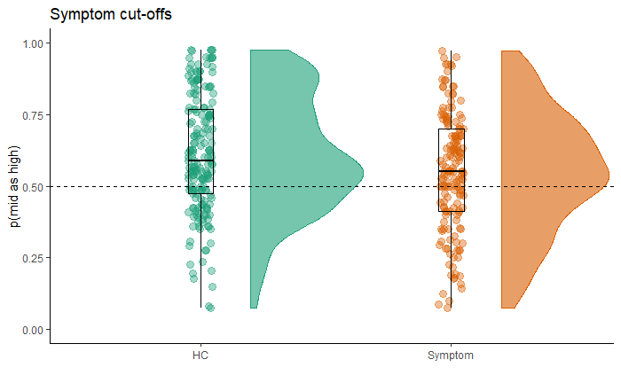

[output not shown]

### II) Latent mixture modelling (data-driven)

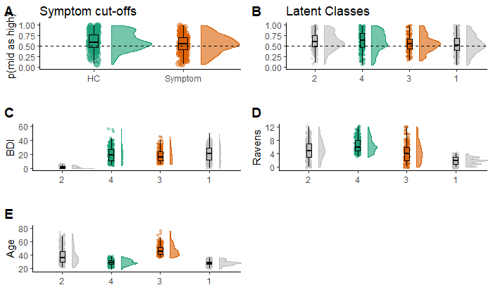

```
----------------------------------------------------
Gaussian finite mixture model fitted by EM algorithm
----------------------------------------------------

Mclust VVE (ellipsoidal, equal orientation) model with 4 components:
```

|  | log-likelihood | n | df | BIC | ICL |
| --- | --- | --- | --- | --- | --- |
|  | -9580.75 | 990 | 30 | -19368.43 | -19807.86 |

```
Clustering table:
  1   2   3   4
298 263 158 271

    Two Sample t-test

data:  Pmid by group
t = 2.233, df = 427, p-value = 0.02607
alternative hypothesis: true difference in means is not equal to 0
95 percent confidence interval:
 0.005697692 0.089449083
sample estimates:
     mean in group HC mean in group Symptom
            0.6090001             0.5614267

[1] "The effect size of the Human group difference on bias is d= 0.22"

    Two Sample t-test

data:  BDI by group
t = 1.9608, df = 427, p-value = 0.05055
alternative hypothesis: true difference in means is not equal to 0
95 percent confidence interval:
 -0.004655391  3.884472291
sample estimates:
     mean in group HC mean in group Symptom
             19.93358              17.99367

[1] "The effect size of the Human group difference is d= 0.2"

    Two Sample t-test

data:  Age by group
t = -31.31, df = 427, p-value < 2.2e-16
alternative hypothesis: true difference in means is not equal to 0
95 percent confidence interval:
 -19.04488 -16.79496
sample estimates:
     mean in group HC mean in group Symptom
             29.16236              47.08228


    Two Sample t-test

data:  Ravens by group
t = 8.3626, df = 427, p-value = 8.772e-16
alternative hypothesis: true difference in means is not equal to 0
95 percent confidence interval:
 1.57889 2.54914
sample estimates:
     mean in group HC mean in group Symptom
             6.627306              4.563291
```

### Exploratory Factor Analysis of questionnaires

The simple regression above, however, collapses across the individual responses to the different items on the questionnaires and just uses summary scores. However, it may be that there is a simpler underlying structure to the data. For instance BDI and STAI are often highly correlated - so may actually be measuring the same latent construct. In this next section (inspired by Gillan et al 2016) we first run an exploratory factor analysis on the individual items from the questionnaires in an attempt to reduce the amount of latent variables.

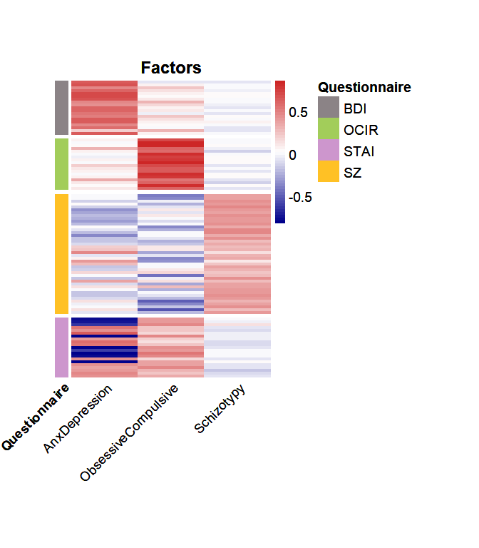

```r
###EFA

#Determine facrors using Cattell-Nelson-Gorsuch CNG Indices (claire's approach)
determinefactors <- nCng(combineditemdata[45:144], cor=TRUE, model="factors")
#Do an EFA using N factors from CNG
efaQaires <- fa(combineditemdata[45:144], nfact = determinefactors$nFactors, rotate = "geominQ", fm = "ml")

efaQaires.loadmat <- zapsmall(matrix(round(efaQaires$loadings, 2), nrow = 100, ncol = 3))
rownames(efaQaires.loadmat) <- names(combineditemdata[45:144])

#heatmap
efaQairesdataf <- data.frame(efaQaires.loadmat)
row.names(efaQairesdataf) <- gsub("_quantised", "", row.names(efaQairesdataf))
names(efaQairesdataf)<-c("AnxDepression","ObsessiveCompulsive","Schizotypy")
annotation <- substr(row.names(efaQairesdataf), start=1, stop=3)
annotationdf <- data.frame(Questionnaire = annotation)
levels(annotationdf$Questionnaire) <- c('BDI', 'OCIR', 'STAI', 'SZ')
rownames(annotationdf) <- rownames(efaQairesdataf)
countqs <- summary(annotationdf$Questionnaire)
qbreaks <- c(countqs[1], (countqs[1]+countqs[2]), (countqs[1]+countqs[2]+countqs[4]) )
ancol = list(Questionnaire =c(BDI ="lavenderblush4", OCIR ="darkolivegreen3", STAI ="plum3",SZ ="goldenrod1"))

heatmapplot <- pheatmap(
  mat               = efaQairesdataf,
  border_color      = NA,
  color             = colorRampPalette(c("darkblue", "white", "firebrick3"))(50),
  cellwidth         = 70,
  cellheight        = 3,
  show_colnames     = TRUE,
  show_rownames     = FALSE,
  drop_levels       = TRUE,
  fontsize          = 14,
  main              = "Factors",
  treeheight_row    = 0,
  treeheight_col    = 0,
  cluster_rows      = FALSE,
  annotation_row    = annotationdf,
  annotation_colors = ancol,
  angle_col         = 45,
  gaps_row          = qbreaks,
  gaps_col          = c(1,2),
  width             = 20,
    height            = 20
)


heatmapplot
```

#### Interpretation

We Identify 3 latent factors using Cattell-Nelson-Gorsuch Indices (as in Gillan et al.). One factor we name “AnxDepression” as it maps closely onto the BDI and STAI , “ObsessiveCompulsive” which is a mix of the OCIR and STAI (and not Schizotypy), and “Schizotypy” which loads positively almost exclusively on the Schizotypy questionnaire.

### Exploratory Structural Equation Model using latent factors

We can now use these factor loadings in an Exploratory Structural Equation Model (ESEM) and run the same regression as above but instead of feeding in the summary questionnaire scores, we can create a latent variable that represents each factor. Of note we use the ‘Robust maximum likelihood’ (MLR) estimator as it is robust to non-normality and the individual items for the questionnaires are not continuous.

```r
##ESEM which mimics regression - this takes the loadings from the EFA and uses them to weight the relationship between each questionnaire item and the three latent factors
terms <- vector()
for (i in 1:3) {
  terms[i] <-
    paste0("F",i,"=~ ", paste0(c(efaQaires.loadmat[,i]), "*", names(efaQaires.loadmat[,1]), collapse = "+"))
}

efaQaires.esem <- paste(terms, collapse = "\n")
##adding the regression and covariances to match the original regression analysis
terms[4] <- "propmedhigh ~ spreadsheet + Ravens + Age + GenderMF + F1 + F2 + F3"
##adding residual correlations
terms[5] <- "spreadsheet ~~ Ravens + Age + GenderMF + F1 + F2 + F3"
terms[6] <- "Ravens ~~ Age  + GenderMF + F1 + F2 + F3"
terms[7] <- "Age ~~  GenderMF + F1 + F2 + F3"
terms[8] <- "GenderMF ~~ F1 + F2 + F3"
terms[9] <- "F1 ~~ F2 + F3"
terms[10] <- "F2 ~~ F3"

semFactorsMatch <- paste(terms, collapse = "\n")

#Fit the model (this takes a while!)
fititem.factors <- sem(semFactorsMatch, data=combineditemdata, meanstructure=TRUE,  estimator = "MLR")

#This plots loads of fit indices, but we are mostly intersted in the regression
summary(fititem.factors, standardized=TRUE, rsquare=F, fit.measures=F)
```

```
lavaan 0.6-5 ended normally after 251 iterations

  Estimator                                         ML
  Optimization method                           NLMINB
  Number of free parameters                        241

                                                  Used       Total
  Number of observations                           986        1060

Model Test User Model:
                                               Standard      Robust
  Test Statistic                              19705.088   17340.173
  Degrees of freedom                               5429        5429
  P-value (Chi-square)                            0.000       0.000
  Scaling correction factor                                   1.136
    for the Yuan-Bentler correction (Mplus variant)

Parameter Estimates:

  Information                                      Observed
  Observed information based on                     Hessian
  Standard errors                        Robust.huber.white

Latent Variables:
                   Estimate  Std.Err  z-value  P(>|z|)   Std.lv  Std.all
  F1 =~
    BDI_Attrctv_qn    0.630                               0.549    0.602
    BDI_Blam_qntsd    0.680                               0.592    0.677
    BDI_Cry_quntsd    0.470                               0.409    0.463
    BDI_Dcsns_qnts    0.600                               0.523    0.595
    BDI_Dsppntmnt_    0.700                               0.610    0.688
    BDI_Falr_qntsd    0.710                               0.618    0.687
    BDI_Futr_qntsd    0.670                               0.584    0.658
    BDI_Glty_qntsd    0.490                               0.427    0.481
    BDI_Hlth_qntsd    0.430                               0.375    0.464
    BDI_Intrs_I_P_    0.600                               0.523    0.593
    BDI_Irrttd_qnt    0.600                               0.523    0.592
    BDI_Libd_qntsd    0.540                               0.470    0.539
    BDI_Pnshd_qnts    0.500                               0.436    0.468
    BDI_Sad_quntsd    0.630                               0.549    0.653
```

[output cut: 387 more lines]

```
   .STAI2_SlfCnfd_    0.742    0.032   23.280    0.000    0.742    0.749
   .STAI2_Stdy_qnt    0.364    0.020   18.411    0.000    0.364    0.492
   .STAI2_Tnsn_qnt    0.451    0.022   20.303    0.000    0.451    0.523
   .STAI2_Thghts_q    0.378    0.019   20.069    0.000    0.378    0.463
   .STAI2_UnmprtT_    0.502    0.022   22.367    0.000    0.502    0.613
   .STAI2_Wrry_qnt    0.572    0.025   22.940    0.000    0.572    0.645
   .STAI_Anxs_qnts    0.539    0.027   20.159    0.000    0.539    0.587
   .propmedhigh       0.042    0.002   24.744    0.000    0.042    0.946
    spreadsheet       8.999    0.006 1547.978    0.000    8.999    1.000
    Ravens            8.675    0.336   25.847    0.000    8.675    1.000
    Age             104.447    6.170   16.927    0.000  104.447    1.000
    GenderMF          0.243    0.003   90.799    0.000    0.243    1.000
    F1                0.759    0.029   26.185    0.000    1.000    1.000
    F2                0.899    0.035   25.559    0.000    1.000    1.000
    F3                0.166    0.011   14.610    0.000    1.000    1.000
```

```r
ESEMfits <-data.frame(fitMeasures(fititem.factors, c("bic","aic","rmsea","rmsea.ci.lower", "rmsea.ci.upper")))
names(ESEMfits) <- "p(mid as high)"
rownames(ESEMfits) <- c("BIC", "AIC", "RMSEA", "RMSEA CI-", "RMSEA CI+")

kable(t(ESEMfits), digits = 3)
```

|  | BIC | AIC | RMSEA | RMSEA CI- | RMSEA CI+ |
| --- | --- | --- | --- | --- | --- |
| p(mid as high) | 199001.6 | 197822.2 | 0.052 | 0.051 | 0.052 |

```r
NA
```

#### Interpretation

In this ESEM we show that the AnxDepression factor (F1) alone significantly influences task performance. Zooming out, both the simple regression and the ESEM agree that of mental health-relevant symptoms, task performance is driven by symptoms of mood and anxiety disorders and not OCD or Psychosis symptoms. This suggests that our original clinical study in mood and anxiety disorders did not reflect a generic pathology, but rather that effects may be selective to the mood and anxiety symptom group that we originally tested. This also suggests that we must also control for age and IQ if we ever want to use this to inform clinical decision-making.

### Potential Confounds

We repated the original regression also including the original factors:

- Spreadsheet (categorical): represents the counterbalancing condition
- Ravens (continuous): IQ measure (visual matrices)
- Age (continuous): years old
- BDI (continuous): Beck depression inventory (suicide question removed)
- STAI2 (continuous): Spielberger Trait Anxiety
- OCIR (continuous): Obsessive-Compulsive Inventory (Revised)
- SZ (continuous): Schizotypal short scale
- GenderMF (categorical): Self-reported gender

As well as potential confounds:

- PastMH (categorical): do you have any past mental health problems?
- CurrentMH (categorical): do you have any current mental health problems?
- SoughtHelp (categorical): have you ever sought help for mental health problems?
- CurrentTreatment (categorical): are you undergoing current treatmend for mental health problems?
- Medication (categorical): are you currently taking medication for mental health problems?
- Family_Schizophrenia (categorical): do you have a family history of schizophrenia?
- Family_Bipolar (categorical): do you have a family history of bipolar disorder?
- Schizophrenia (categorical): do you have a current diagnosis of schizophrenia?
- Bipolar (categorical): do you have a current diagnosis of bipolar disorder?
- Neurological_Disorder (categorical): do you currently have a neurological disorder?
- TakeDrugs (categorical): do you take recreational drugs?
- DrinkAlcohol (categorical): do you drink alcohol?
- Learning_Disability (categorical): do you have a learning disability?

```r
NegBiasconfmodel <- 'propmedhigh ~ GenderMF + Age + Ravens + spreadsheet +BDI + STAI2 + SZ + OCIR + PastMH + CurrentMH + SoughtHelp + CurrentTreatment + Medication + Family_Schizophrenia + Family_Bipolar + Schizophrenia + Bipolar + Neurological_Disorder + TakeDrugs + DrinkAlcohol + Learning_Disability'


fitconf <- sem(NegBiasconfmodel, data=combineditemdata, meanstructure=TRUE,  estimator = "MLR")

summary(fitconf, standardized=TRUE, rsquare=T, fit.measures=F) #p(mid as high) including all potential confounds
```

```
lavaan 0.6-5 ended normally after 72 iterations

  Estimator                                         ML
  Optimization method                           NLMINB
  Number of free parameters                         23

                                                  Used       Total
  Number of observations                           986        1060

Model Test User Model:
                                              Standard      Robust
  Test Statistic                                 0.000       0.000
  Degrees of freedom                                 0           0

Parameter Estimates:

  Information                                      Observed
  Observed information based on                     Hessian
  Standard errors                        Robust.huber.white

Regressions:
                   Estimate  Std.Err  z-value  P(>|z|)   Std.lv  Std.all
  propmedhigh ~
    GenderMF          0.021    0.014    1.550    0.121    0.021    0.050
    Age              -0.002    0.001   -3.369    0.001   -0.002   -0.107
    Ravens            0.009    0.002    3.917    0.000    0.009    0.133
    spreadsheet       0.006    0.002    2.641    0.008    0.006    0.082
    BDI              -0.002    0.001   -2.411    0.016   -0.002   -0.124
    STAI2             0.000    0.001    0.430    0.667    0.000    0.022
    SZ               -0.001    0.001   -0.904    0.366   -0.001   -0.049
    OCIR              0.000    0.001    0.383    0.702    0.000    0.019
    PastMH           -0.004    0.019   -0.232    0.816   -0.004   -0.010
    CurrentMH         0.016    0.019    0.806    0.420    0.016    0.033
    SoughtHelp        0.030    0.018    1.671    0.095    0.030    0.071
    CurrentTretmnt   -0.017    0.022   -0.782    0.434   -0.017   -0.038
    Medication        0.002    0.020    0.122    0.903    0.002    0.006
    Famly_Schzphrn   -0.027    0.021   -1.291    0.197   -0.027   -0.053
    Family_Bipolar   -0.013    0.018   -0.709    0.478   -0.013   -0.026
    Schizophrenia     0.045    0.028    1.592    0.111    0.045    0.073
    Bipolar          -0.018    0.023   -0.793    0.428   -0.018   -0.033
    Neurlgcl_Dsrdr   -0.012    0.022   -0.530    0.596   -0.012   -0.020
    TakeDrugs         0.011    0.015    0.765    0.444    0.011    0.027
    DrinkAlcohol     -0.009    0.014   -0.631    0.528   -0.009   -0.020
    Learnng_Dsblty   -0.007    0.020   -0.321    0.748   -0.007   -0.012

Intercepts:
                   Estimate  Std.Err  z-value  P(>|z|)   Std.lv  Std.all
   .propmedhigh       0.647    0.057   11.324    0.000    0.647    3.088

Variances:
                   Estimate  Std.Err  z-value  P(>|z|)   Std.lv  Std.all
   .propmedhigh       0.041    0.002   24.789    0.000    0.041    0.935

R-Square:
                   Estimate
    propmedhigh       0.065
```

#### Interpretation

Current diagnosis or treatment factors do not confound the primary inference.

### Raw correlation with other questionnaires

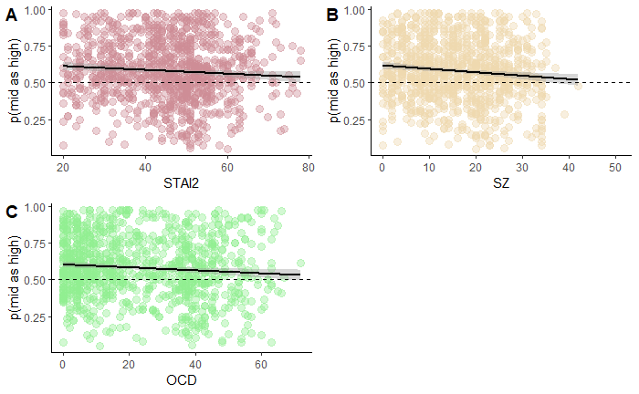

```r
cc1 <- ggplot(combineditemdata, aes(x=combineditemdata$STAI2, y=combineditemdata$propmedhigh)) +
  geom_point(size = 3, alpha = 0.4,color="lightpink3", fill="lightpink3") +    # Use hollow circles
  geom_smooth(method=lm, colour="black")+   # Add linear regression line
  ylab('p(mid as high)')+guides(fill = FALSE, col = FALSE)+
  xlab('STAI2')+guides(fill = FALSE, col = FALSE)
cc1 <- cc1 + geom_hline(yintercept=0.5, linetype="dashed")+ theme_classic()
#cc1 <- cc1 + xlim(c(0,60))


cc2 <- ggplot(combineditemdata, aes(x=combineditemdata$SZ, y=combineditemdata$propmedhigh)) +
  geom_point(size = 3, alpha = 0.4,color="wheat2", fill="wheat2") +    # Use hollow circles
  geom_smooth(method=lm, colour="black")+   # Add linear regression line
  ylab('p(mid as high)')+guides(fill = FALSE, col = FALSE)+
  xlab('SZ')+guides(fill = FALSE, col = FALSE)
cc2 <- cc2 + geom_hline(yintercept=0.5, linetype="dashed")+ theme_classic()
#cc2 <- cc2 + xlim(c(0,60))

cc3 <- ggplot(combineditemdata, aes(x=combineditemdata$OCIR-18, y=combineditemdata$propmedhigh)) +
  geom_point(size = 3, alpha = 0.4,color="palegreen2", fill="palegreen2") +    # Use hollow circles
  geom_smooth(method=lm, colour="black")+   # Add linear regression line
  ylab('p(mid as high)')+guides(fill = FALSE, col = FALSE)+
  xlab('OCD')+guides(fill = FALSE, col = FALSE)
cc3 <- cc3 + geom_hline(yintercept=0.5, linetype="dashed")+ theme_classic()
#cc3 <- cc3 + xlim(c(0,60))

Bothcorr <- plot_grid(cc1, cc2, cc3, labels="AUTO")
Bothcorr
```

```r
cor.test(x=combineditemdata$STAI2, y=combineditemdata$propmedhigh, use = "pairwise.complete.obs")
```

```
    Pearson's product-moment correlation

data:  combineditemdata$STAI2 and combineditemdata$propmedhigh
t = -2.3763, df = 988, p-value = 0.01768
alternative hypothesis: true correlation is not equal to 0
95 percent confidence interval:
 -0.13704673 -0.01314108
sample estimates:
        cor
-0.07538489
```

```r
cor.test(x=combineditemdata$SZ, y=combineditemdata$propmedhigh, use = "pairwise.complete.obs")
```

```
    Pearson's product-moment correlation

data:  combineditemdata$SZ and combineditemdata$propmedhigh
t = -3.3047, df = 988, p-value = 0.000985
alternative hypothesis: true correlation is not equal to 0
95 percent confidence interval:
 -0.16578540 -0.04253145
sample estimates:
       cor
-0.1045599
```

```r
cor.test(x=combineditemdata$OCIR, y=combineditemdata$propmedhigh, use = "pairwise.complete.obs")
```

```
    Pearson's product-moment correlation

data:  combineditemdata$OCIR and combineditemdata$propmedhigh
t = -2.7855, df = 988, p-value = 0.005447
alternative hypothesis: true correlation is not equal to 0
95 percent confidence interval:
 -0.14975363 -0.02610979
sample estimates:
        cor
-0.08827172
```

#### Interpretation

STAI (r=-0.08, p=0.018), SZ (r=-0.10, p<0.001) and OCD (r=-0.09,p=0.005) predict p(mid as high) they just do not do so over and above the effect of BDI (r=-0.13, p<0.001).

### Exclude fast RTs

```r
NoFastRTs=subset(combineditemdata,
                 meanlowRT > (mean(na.omit(combineditemdata$meanlowRT))-2*(sd(na.omit(combineditemdata$meanlowRT)))))

NegBiasmodel.1 <- 'propmedhigh ~ GenderMF + Age + Ravens + spreadsheet +BDI + STAI2 + SZ + OCIR'
NegBiasmodel.2 <- 'driftrate ~ GenderMF + Age + Ravens + spreadsheet +BDI + STAI2 + SZ + OCIR'


fit1 <- sem(NegBiasmodel.1, data=NoFastRTs, meanstructure=TRUE,  estimator = "MLR")
fit2 <- sem(NegBiasmodel.2, data=NoFastRTs, meanstructure=TRUE,  estimator = "MLR")
fit1miss <- sem(NegBiasmodel.1, data=NoFastRTs, meanstructure=TRUE,  estimator = "MLR", missing = "ML")
fit2miss <- sem(NegBiasmodel.2, data=NoFastRTs, meanstructure=TRUE,  estimator = "MLR", missing = "ML")



summary(fit1, standardized=TRUE, rsquare=T, fit.measures=F) #p(mid as high) listwise delete missing
summary(fit2, standardized=TRUE, rsquare=T, fit.measures=F) #driftrate listwise delete missing
summary(fit1miss, standardized=TRUE, rsquare=T, fit.measures=F) #p(mid as high) estimate missing
summary(fit2miss, standardized=TRUE, rsquare=T, fit.measures=F) #drift rate estimate missing
```

[output not shown]